[figure not shown]

WI-424

Bulkhead Wiring Harness (In Engine Compartment) RH

WIRING SYSTEM

62.Bulkhead Wiring Harness (In Engine Compartment) RH

A: LOCATION

1. ENGINE TYPE FA

Connector Connecting to

No. Pole Color Area No. Description

AB16 2 Y D-1 Front sub sensor RH

B3 5 B C-2 Mass air flow and intake air temperature sensor

B6 2 GR C-3 Front ABS wheel speed sensor RH

B11 20 GR C-5 T4

Transmission cord (CVT model)

B12 12 B C-4 T3

B14 1 B C-5 Starter motor

B22 16 BR C-4 E3 Engine wiring harness

B24 2 GR C-4 T1 Back-up light switch (MT model)

B25 2 BR C-4 T2 Neutral position switch 1 (MT model)

B122 8 GR B-3 J/C

B134 48 BR C-3 ECM

B164 2 GR C-1 Keyless buzzer

B177 2 GR B-5 Wiper deicer

B310 38 B-2 VDC CM

B321 2 B C-3 Hood switch

B450 10 B B-3 Power steering CM

B451 5 GR B-3 Torque sensor

B452 2 B B-3 Power steering CM

: White or natural color

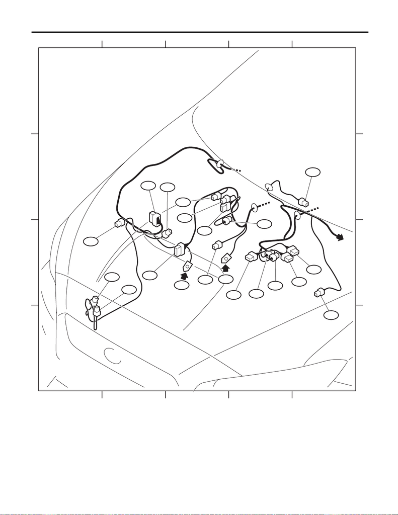

WI-425

Bulkhead Wiring Harness (In Engine Compartment) RH

WIRING SYSTEM

WI-44612

12345

12345

A

B

C

D

A

B

C

D

LH

B450

B452

B122

B451

B177

B310

B321

B134

B6

B3

AB16

B164

B24

B22

B14

B12

B11

B25

GV

GAP

[figure not shown]

WI-426

Bulkhead Wiring Harness (In Engine Compartment) RH

WIRING SYSTEM

2. ENGINE TYPE EJ

Connector Connecting to

No. Pole Color Area No. Description

AB16 2 Y D-1 Front sub sensor RH

B3 5 B C-2 Mass air flow and intake air temperature sensor

B6 2 GR C-3 Front ABS wheel speed sensor RH

B14 1 B C-5 Starter motor

B19 4 GR C-4 T5 Transmission cord

B21 54 B B-3 E2 Engine wiring harness

B128 6 GR C-5 T9 Transmission cord

B164 2 GR C-1 Keyless buzzer

B177 2 GR B-5 Wiper deicer

B310 38 B-2 VDC CM

B321 2 B C-3 Hood switch

B379 4 GR B-3 Front oxygen (A/F) sensor

: White or natural color

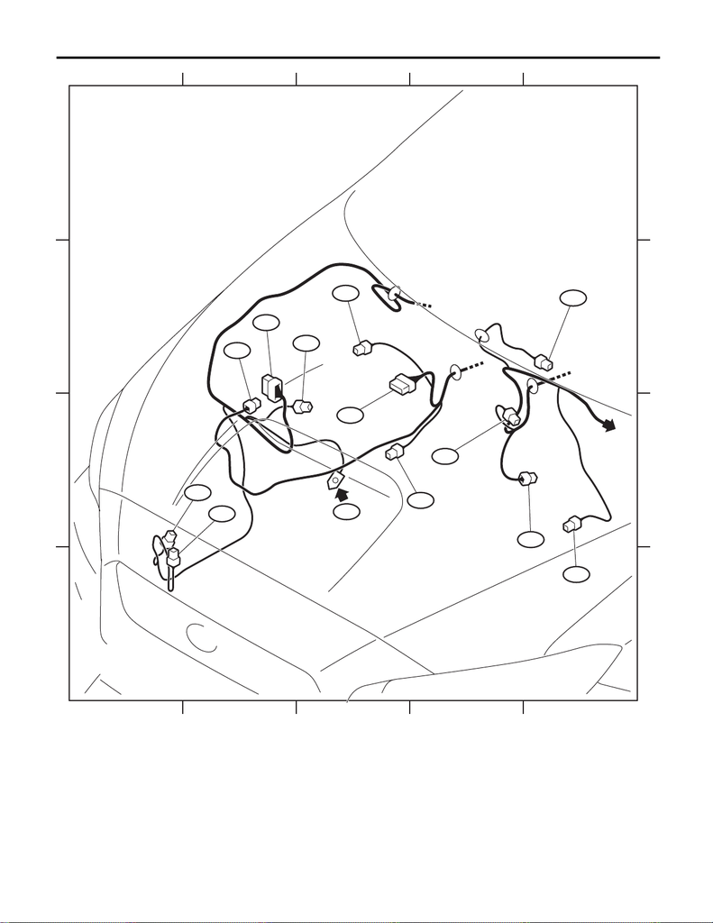

WI-427

Bulkhead Wiring Harness (In Engine Compartment) RH

WIRING SYSTEM

WI-44614

12345

12345

A

B

C

D

A

B

C

D

LH

B321

B310

B3

B379

AB16

B164

B14

B128

B177

B19

B21

B6

GV